# Loading packages

```r
library(tidyverse)
library(lubridate)
library(normalr)
library(formatR)
```

# Welcome to my presentation

This is a presentation about my own company “Verture Farm”. This data is saved about the month Juli, August, September and October. First of all i will look on some visualizations about the harvest data and analyse it. After that i want to add the weather data to the harvest data to analyse the dependency between the amount of harvest and the weather.

# Load Data

First of all we have to load the data.

```r
df <- readRDS("Erntetabelle.rds")
```

Than lets view the data.

```r
# view(df)
```

We see that there a lot of NA values. Lets tidy up the NA values.

```r
df <- df %>% select(-`Packungen Verkauft Marktschwärmer`) %>% drop_na()
```

Manipulate the Date and add an interval, week and some other columns.

```r
df$Erntedatum <- ymd(df$Erntedatum)
df$Aussaat <- ymd(df$Aussaat)

df <- df %>% mutate(Zeitstrecke = interval(ymd(Aussaat), ymd(Erntedatum)))

df <- df %>% mutate(woche = week(df$Erntedatum))
```

If you want to save all your datawrangling than use the save function.

```r
# saveRDS(df,'Erntetabelle.rds)
```

# The average amount of harvest

Here we get the average amount of harvest per variety. I filtert out the varieties where we only got a few crops. So we concentrate on the varieties which are common. There “Radieschen rot”, “Daikon Rettich”, “Brokkoli”, “Senf”, “Sonnenblumen” und “Erbsen”.

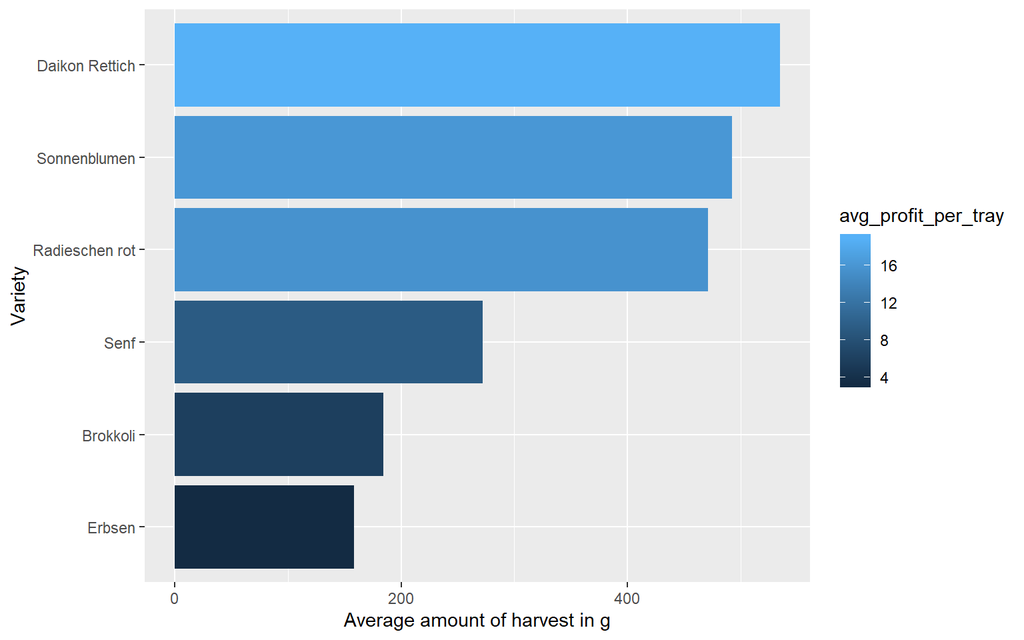

```r
df %>% filter(Sorte != "Bockshornklee", Sorte != "Mizuna", Sorte != "Rote Bete",
    Sorte != "Kohlrabi rot", Sorte != "Koriander") %>% group_by(Sorte) %>% summarise(Durchschnittserntemenge = mean(`Geerntet in gramm`/`Anzahl Trays`),
    avg_profit_per_tray = mean(`Gewinn pro Tray bei Marktschwärmer`)) %>% ggplot(aes(x = reorder(Sorte,
    Durchschnittserntemenge), y = Durchschnittserntemenge, fill = avg_profit_per_tray)) +
    geom_col() + coord_flip() + xlab("Variety") + ylab("Average amount of harvest in g")
```

# Average time of grown

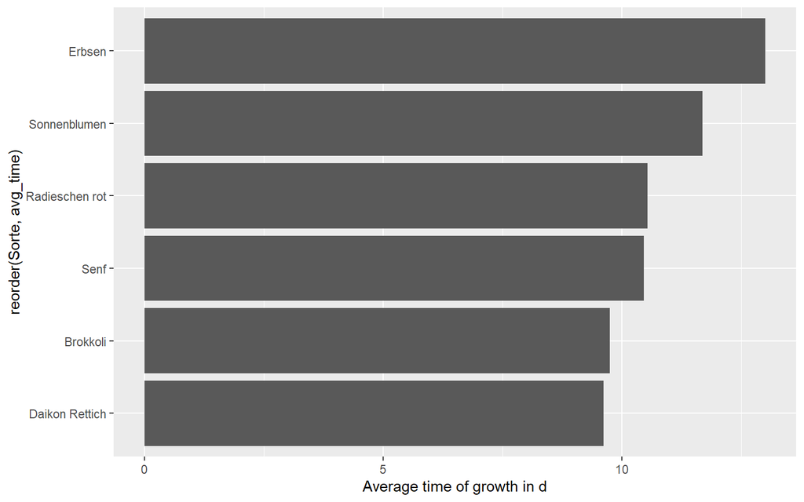

```r
df %>% filter(Sorte != "Bockshornklee", Sorte != "Mizuna", Sorte != "Rote Bete",
    Sorte != "Kohlrabi rot", Sorte != "Koriander") %>% group_by(Sorte) %>% summarise(avg_time = mean(Anbauzeit)) %>%
    ggplot(aes(x = reorder(Sorte, avg_time), y = avg_time)) + geom_col() + coord_flip() +
    ylab("Average time of growth in d")
```

# Time of growth over time

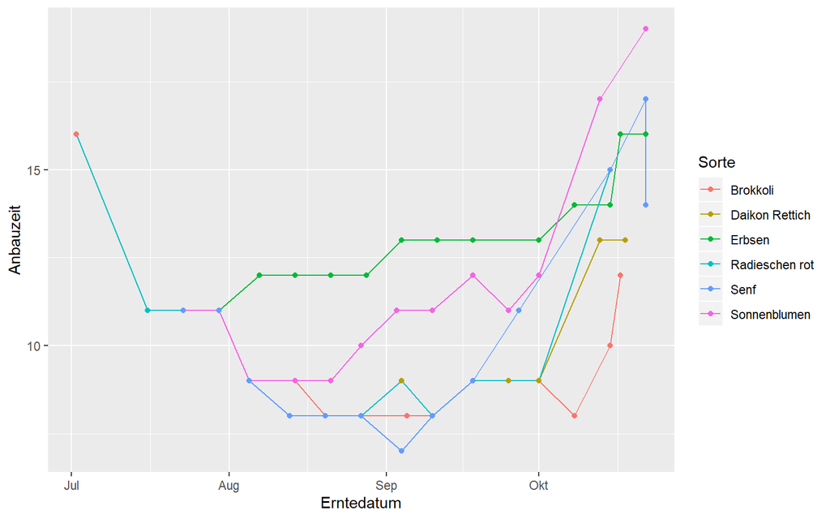

```r
df %>% filter(Sorte != "Bockshornklee", Sorte != "Mizuna", Sorte != "Rote Bete",
    Sorte != "Kohlrabi rot", Sorte != "Koriander") %>% group_by(Sorte) %>% ggplot(aes(x = Erntedatum,
    y = Anbauzeit, colour = Sorte)) + geom_line() + geom_point()
```

# Lets look some variables over time

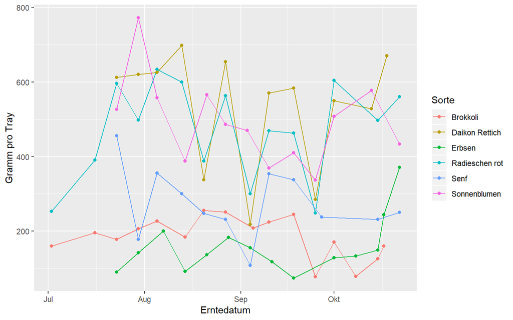

```r
df %>% filter(Sorte != "Bockshornklee", Sorte != "Mizuna", Sorte != "Rote Bete",
    Sorte != "Kohlrabi rot", Sorte != "Koriander") %>% ggplot(aes(x = Erntedatum,
    y = `Gramm pro Tray`, colour = Sorte)) + geom_line() + geom_point()
```

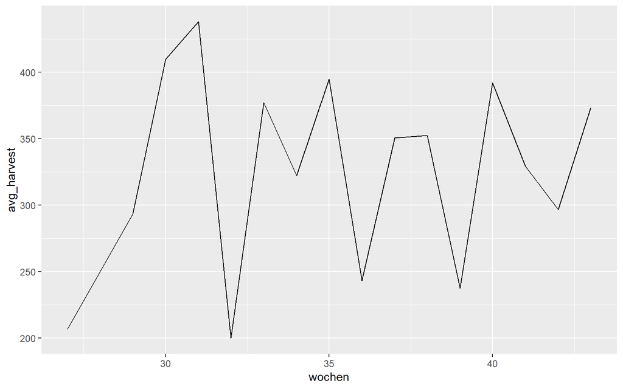

```r
df %>% filter(Sorte != "Bockshornklee", Sorte != "Mizuna", Sorte != "Rote Bete",
    Sorte != "Kohlrabi rot", Sorte != "Koriander") %>% group_by(wochen = week(Erntedatum)) %>%
    summarise(avg_harvest = mean(`Gramm pro Tray`)) %>% ggplot(aes(x = wochen,
    y = avg_harvest)) + geom_line()
```

Lets add the filter function to our data.frame.

```r
df1 <- df %>% filter(Sorte != "Bockshornklee", Sorte != "Mizuna", Sorte != "Rote Bete",
    Sorte != "Kohlrabi rot", Sorte != "Koriander")
```

# Amount of Trays

```r
df %>% summarise(AmountTrays = sum(`Anzahl Trays`, na.rm = TRUE))
```

```
# A tibble: 1 x 1
  AmountTrays
        <dbl>
1        152.
```

```r
df %>% summarise(PossibleProfit = sum(`Anzahl Trays`, na.rm = TRUE) * 450/1000 *
    30)
```

```
# A tibble: 1 x 1
  PossibleProfit
           <dbl>
1          2045.
```

# Lets check the weather

First of all we have to load some data.

```r
produkt_klima_tag_20180517_20191117_02564 <- read_delim("dataaktl/produkt_klima_tag_20180517_20191117_02564.txt",
    ";", escape_double = FALSE, trim_ws = TRUE)
```

Lets put the original data to a other data.frame and change the date column.

```r
weather <- produkt_klima_tag_20180517_20191117_02564
weather$MESS_DATUM <- ymd(weather$MESS_DATUM)
```

Lets have a look on the weather data with a little plot but beforehand we shut just choose the date where the farm was producing. Here we see the column names and their meaning.

FM : Daily mean of the wind speed in m/s FX : Maxima of the wind peak m/sec NM : Tagesmittel des Bedeckungsgrades in Achteln PM : Tagesmittel des Luftdrucks in hpa RSK : tgl. Niederschlagshöhe in mm RSKF : tgl. Niederschlagsform im numerischen Code SDK : Sonnenscheindauer in h SHK_TAG : Schneehoeher Tageswert in cm TGK : Minimum der Lufttemperatur am ERdboden in 5 cm Hoehe in °C TMK : Tagesmittel der Temperatur in °C TNK : Tagesminimum der Lufttemperatur in 2 m Hoehe in °C TXK : Tagesmaximum der Lufttemperatur in 2 m Hoehe in °C UPM : Tagesmittel der Relativen Feuchte in % VPM : Tagesmittel des DAmpfdruckes in hpa

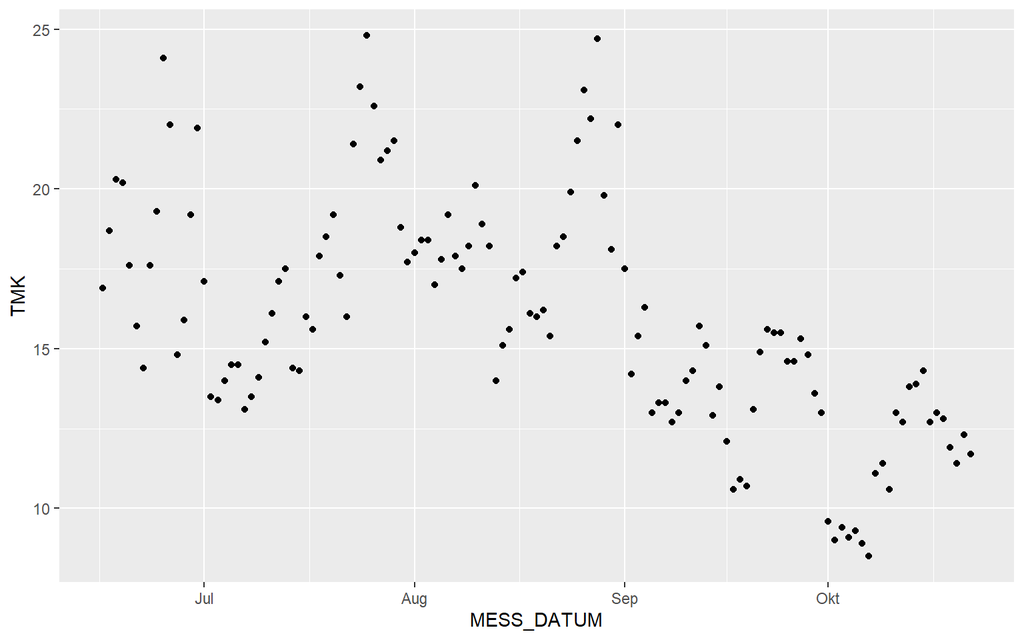

```r
weather <- weather %>% filter(year(weather$MESS_DATUM) == 2019, yday(weather$MESS_DATUM) >=
    167, yday(weather$MESS_DATUM) <= 295)

weather <- weather %>% mutate(woche = week(weather$MESS_DATUM))

weather %>% ggplot(aes(x = MESS_DATUM, y = TMK)) + geom_point()
```

```r
# year(weather$MESS_DATUM) # Gibt das Jahr aus für alle Daten im df
# date(weather$MESS_DATUM) # Gibt das Datum aus für alle Daten im df
# ymd(20190616) # Gibt das Datum für den eingegebenen Zeitpunkt aus
# yday(ymd(20191022)) # Gibt den Tag im Jahr aus für das eingegebene Datum
# yday(weather$MESS_DATUM) # Gibt den Tag im Jahr für alle Daten im df
# weather$MESS_DATUM # Gibt alle Daten aus für alle Daten im df
```

Try to get information for the plots from two different datasets.

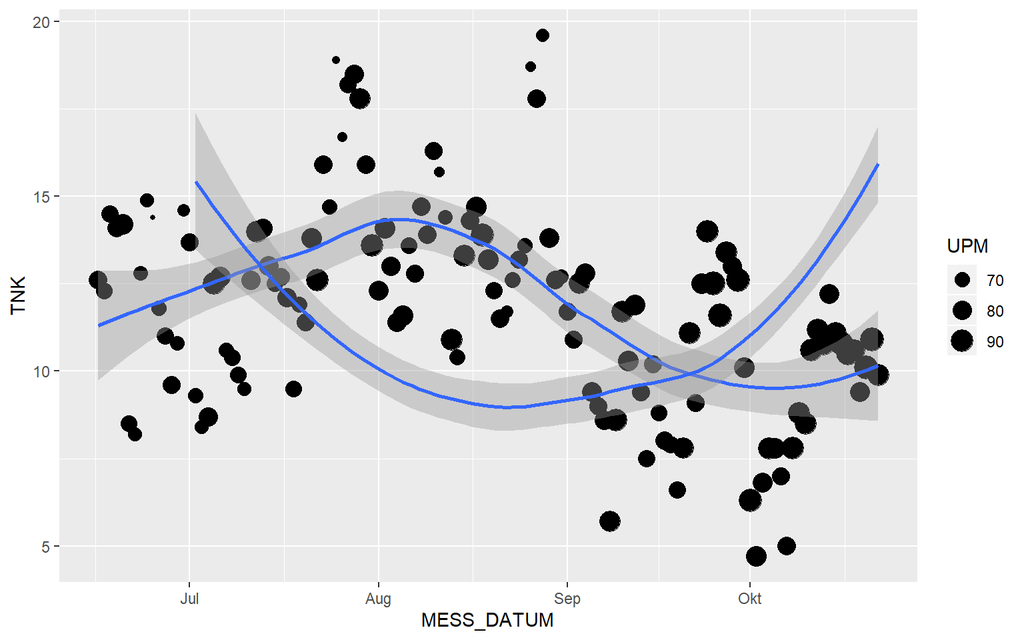

```r
ggplot() + geom_point(data = weather, aes(x = MESS_DATUM, y = TNK, size = UPM)) +
    geom_smooth(data = weather, aes(x = MESS_DATUM, y = TNK)) + geom_smooth(data = df1,
    aes(x = Erntedatum, y = Anbauzeit), show.legend = FALSE)
```

Take a look on the average harvest about the weeks.

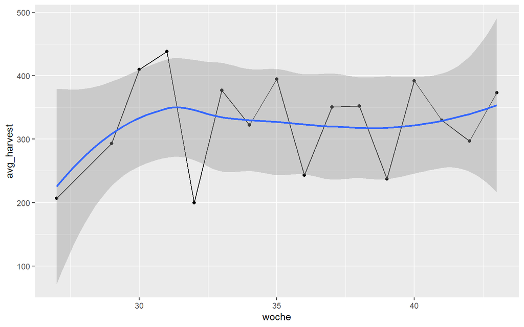

```r
p1 <- df2 %>% group_by(woche)

p1 %>% summarise(avg_harvest = mean(`Gramm pro Tray`)) %>% ggplot(aes(x = woche,
    y = avg_harvest)) + geom_point() + geom_line() + geom_smooth()
```

Create a line for every variety.

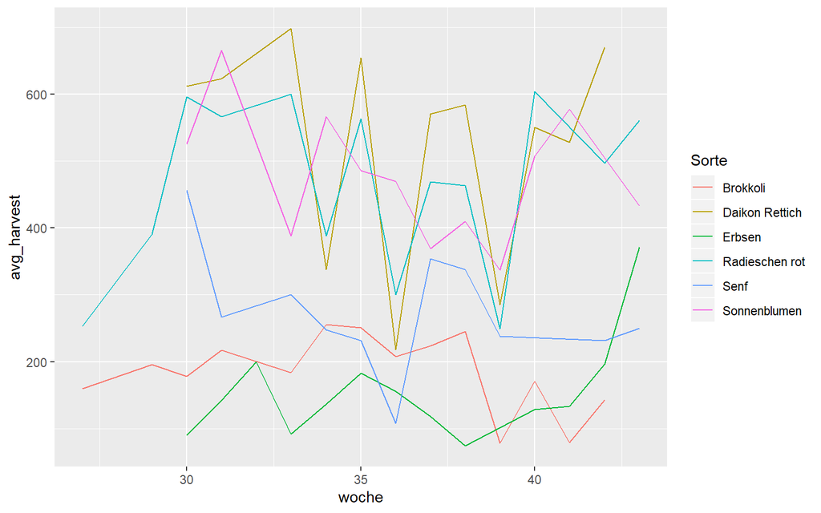

```r
p2 <- df2 %>% group_by(woche, Sorte)

p2 %>% summarise(avg_harvest = mean(`Gramm pro Tray`)) %>% ggplot(aes(x = woche,
    y = avg_harvest, colour = Sorte)) + geom_line()
```

Add some more layers and tidy up the varieties.

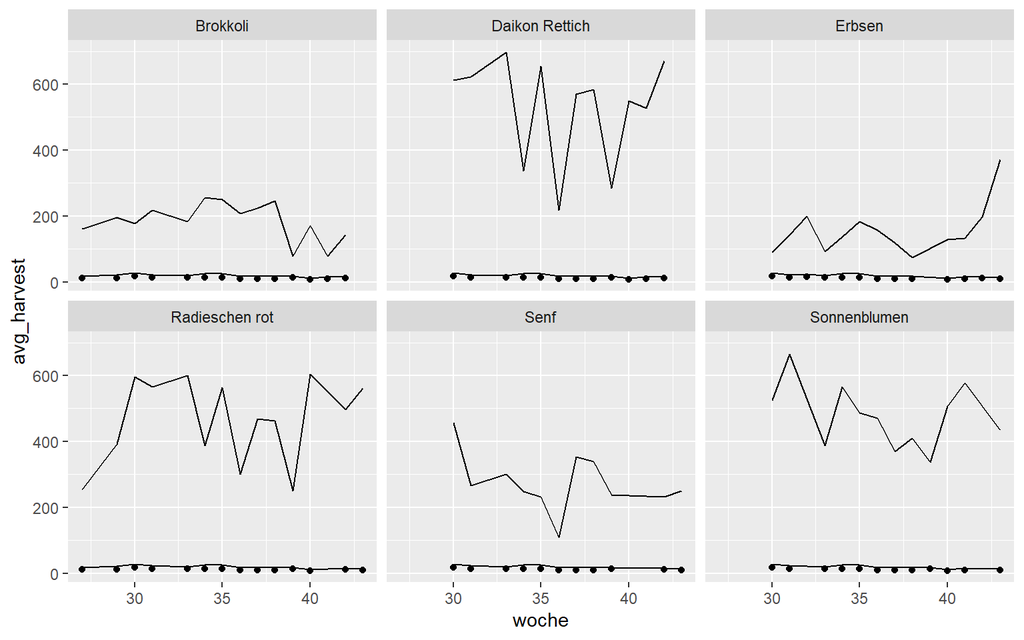

```r
p2 <- p2 %>% summarise(avg_harvest = mean(`Gramm pro Tray`)) %>% ggplot(aes(x = woche,
    y = avg_harvest)) + geom_line()



p2 + geom_point(data = df2, aes(x = woche, y = avg_tnk_week), colour = "black") +
    geom_line(data = df2, aes(x = woche, y = avg_txk_week), colour = "black") +
    facet_wrap(~Sorte)
```

To put the two datasets into one plot we have to normalize the numeric numbers.

```r
help("scale")
# normalise(df)
```

2019-11-25